# Final Presentation Template

Lyndon Estes

4/29/2020

# Introduction

- An example set of slides for final class presentations
- With demo for displays of code the executes when knitting
- And for code that displays results of code that executes offline

# Results from code executing at knit-time

```r
# uncomment and run the next line if you don't have geospaar installed
devtools::install_github("agroimpacts/geospaar")
library(geospaar)
library(sf)
library(ggplot2)

dists <- read_sf(system.file("extdata/districts.shp", package = "geospaar"))
```

# Results from executed code, plotted

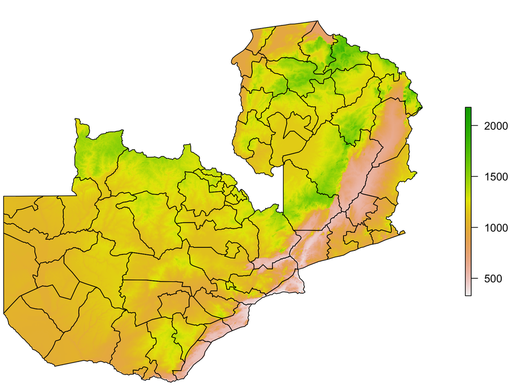

```r
plot_noaxes(dem)
plot(st_geometry(dists), add = TRUE)
```

# Results from “offline” code

Code chunk that does the analysis but saves results (in this case a png)

```r
library(geospaar)
library(sf)
library(ggplot2)
data("zamprec")
dists <- read_sf(system.file("extdata/districts.shp", package = "geospaar"))
mymean <- function(x, na.rm = na.rm) mean(x, na.rm = na.rm)
rfmu <- raster::extract(zamprec, dists, fun = mymean, na.rm = TRUE)
dists <- dists %>% dplyr::mutate(rain = rfmu)

# use png to save plot on disk with plot.sf
png(filename = here::here("materials/slides/figures/demo_rain_sf.png"),
    height = 4, width = 4, res = 300, units = "in")
plot(dists["rain"], main = NULL)
dev.off()

# use ggsave with ggplot figures
p <- ggplot(dists) + geom_sf(aes(fill = rain)) + theme_linedraw()
ggsave(p, filename = here::here("materials/slides/figures/demo_rain_gg.png"),
       height = 4, width = 4, dpi = 300)
```

# Results from offline code, plotted 1

`plot.sf` version (hint: look at the .Rmd to see the hidden code that plots this)

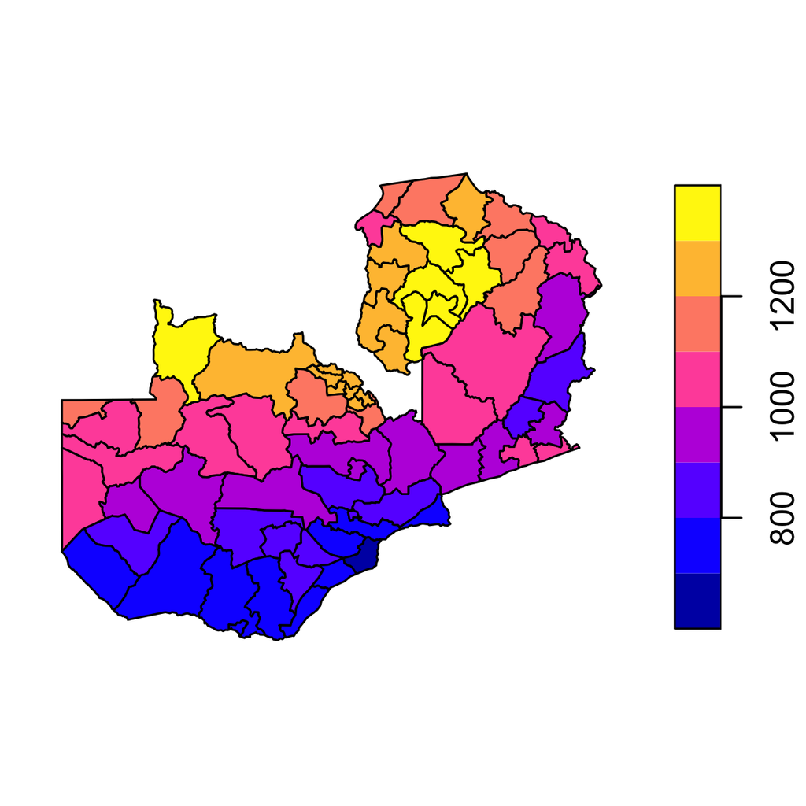

# Results from offline code, plotted 2

`ggplot` version

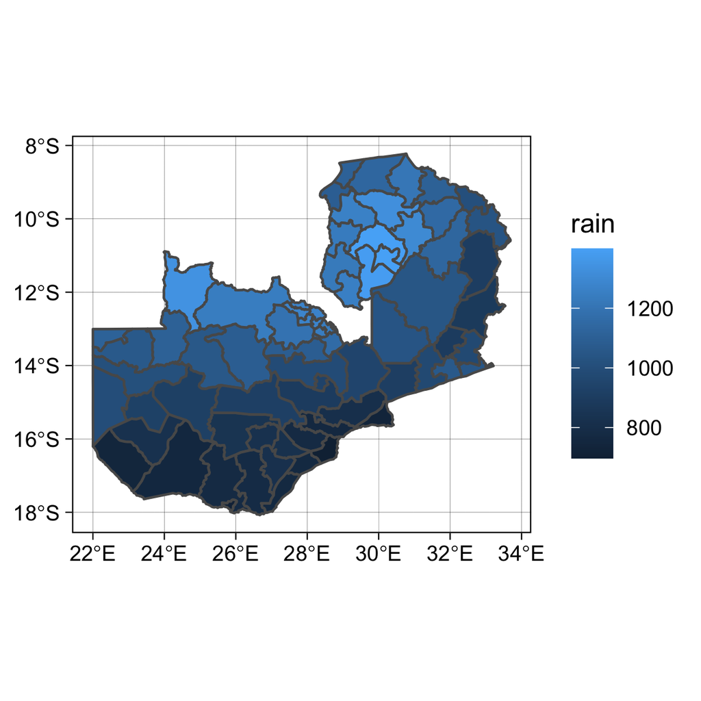

# Save analytical results “offline”

To use in downstream chunk. Good for cases where analysis takes a long time to execute

Here is the offline analysis (code chunk set to `eval=FALSE`)

```r
tri <- raster::terrain(dem, opt = "TRI")
save(tri, file = here::here("materials/slides/output/tri.rda"))
```

# Plot saved results in live chunk

After the long analysis runs and saves the results, you can read it back in to a “live” chunk (one that executes at knit-time) and do something with it.

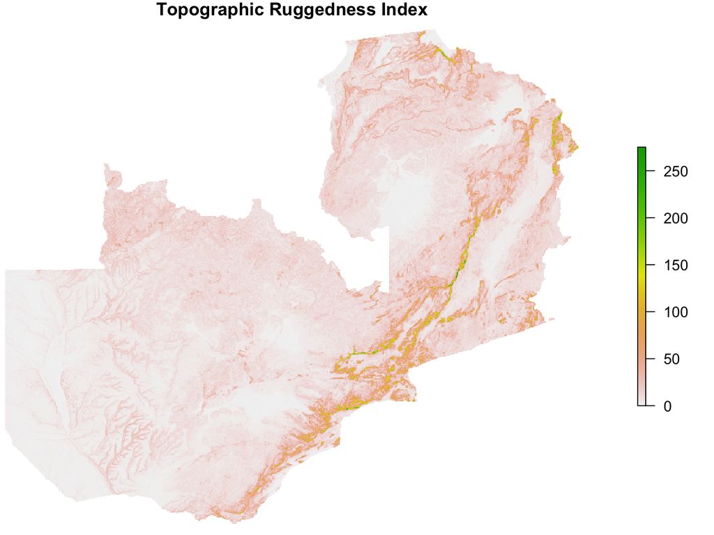

```r
load(here::here("materials/slides/output/tri.rda"))
plot_noaxes(tri, main = "Topographic Ruggedness Index")
```

# Final words

- The examples above apply to both vignettes and slides
- You can choose ioslides or slidy versions of the presentations
- Both versions are offered in RMarkdown presentation templates (see File > New File > R Markdown > Presentation)
- This example uses slidy